# activity02

2024-01-23

#Libraries

[output not shown]

#Uploading the data

```
## # A tibble: 6 × 123
##    year ISO_code countries region pf_rol_procedural pf_rol_civil pf_rol_criminal
##   <dbl> <chr>    <chr>     <chr>              <dbl>        <dbl>           <dbl>
## 1  2016 ALB      Albania   Easte…              6.66         4.55            4.67
## 2  2016 DZA      Algeria   Middl…             NA           NA              NA
## 3  2016 AGO      Angola    Sub-S…             NA           NA              NA
## 4  2016 ARG      Argentina Latin…              7.10         5.79            4.34
## 5  2016 ARM      Armenia   Cauca…             NA           NA              NA
## 6  2016 AUS      Australia Ocean…              8.44         7.53            7.36
## # ℹ 116 more variables: pf_rol <dbl>, pf_ss_homicide <dbl>,
## #   pf_ss_disappearances_disap <dbl>, pf_ss_disappearances_violent <dbl>,
## #   pf_ss_disappearances_organized <dbl>,
## #   pf_ss_disappearances_fatalities <dbl>, pf_ss_disappearances_injuries <dbl>,
## #   pf_ss_disappearances <dbl>, pf_ss_women_fgm <dbl>,
## #   pf_ss_women_missing <dbl>, pf_ss_women_inheritance_widows <dbl>,
## #   pf_ss_women_inheritance_daughters <dbl>, pf_ss_women_inheritance <dbl>, …
```

```
## Rows: 1,458
## Columns: 123
## $ year                               <dbl> 2016, 2016, 2016, 2016, 2016, 2016,…
## $ ISO_code                           <chr> "ALB", "DZA", "AGO", "ARG", "ARM", …
## $ countries                          <chr> "Albania", "Algeria", "Angola", "Ar…
## $ region                             <chr> "Eastern Europe", "Middle East & No…
## $ pf_rol_procedural                  <dbl> 6.661503, NA, NA, 7.098483, NA, 8.4…
## $ pf_rol_civil                       <dbl> 4.547244, NA, NA, 5.791960, NA, 7.5…
## $ pf_rol_criminal                    <dbl> 4.666508, NA, NA, 4.343930, NA, 7.3…
## $ pf_rol                             <dbl> 5.291752, 3.819566, 3.451814, 5.744…
## $ pf_ss_homicide                     <dbl> 8.920429, 9.456254, 8.060260, 7.622…
## $ pf_ss_disappearances_disap         <dbl> 10, 10, 5, 10, 10, 10, 10, 10, 10, …
## $ pf_ss_disappearances_violent       <dbl> 10.000000, 9.294030, 10.000000, 10.…
## $ pf_ss_disappearances_organized     <dbl> 10.0, 5.0, 7.5, 7.5, 7.5, 10.0, 10.…
## $ pf_ss_disappearances_fatalities    <dbl> 10.000000, 9.926119, 10.000000, 10.…
```

[output cut: 110 more lines]

- I opted to download the hfi data file directly after few issues fetching it directly.
- 1.What are the dimensions of the dataset? 1458 Observations (rows) and 123 variables (columns)

  What does each row represent? - Each row represent the individual record of every attribute/variable.

#Fltering the 2016 Data and creating a dataframe

[output not shown]

[output cut: 272 more lines]

## 1. Identify our research question(s)

Today’s research question/goal is to predict a country’s personal freedom score in 2016.

For this activity we want to explore the relationship between the personal freedom score, `pf_score`, and the political pressures and controls on media content index,`pf_expression_control`. Specifically, we are going to use the political pressures and controls on media content index to predict a country’s personal freedom score in 2016.

### 2. Explore the variables of interest

Answer the following questions (use your markdown skills) and complete the following tasks.

2. What type of plot would you use to display the distribution of the personal freedom scores, `pf_score`? : **A histogram because the pf-score data is continuous.

Would this be the same type of plot to display the distribution of the political pressures and controls on media content index, `pf_expression_control`? ** pf_expression_control would also be represented using histogram for the same reason.

#Histogram for pf_expression_control and pf_score (Both are continuous)

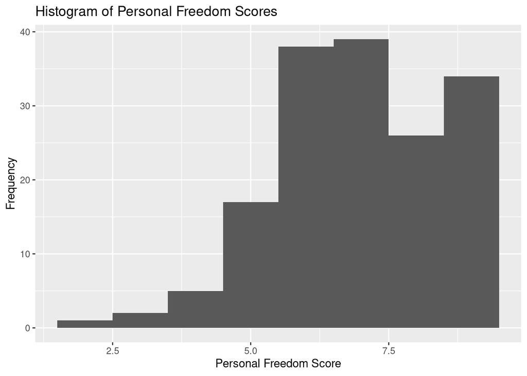

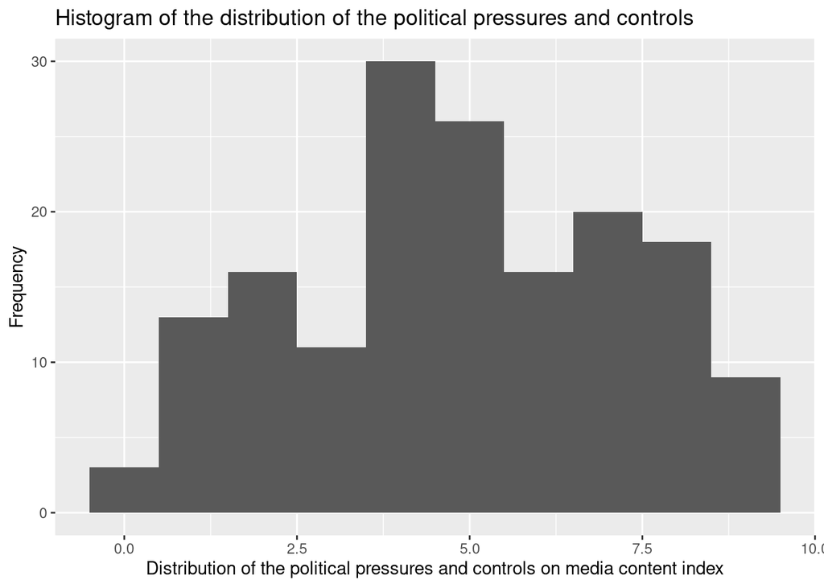